# Homework 4

Vaishnavi Maganti

2026-01-15

## Instructions

Answer the following questions and/or complete the exercises in RMarkdown. Please embed all of your code and push the final work to your repository. Your report should be organized, clean, and run free from errors. Remember, you must remove the `#` for any included code chunks to run. Any plots must have appropriate titles and aesthetics.

## Load the tidyverse

```r
library("tidyverse")
options(scipen = 999) #disable scientific notation
```

For this homework, we will be using the `msleep` dataset from the `ggplot2` package. This dataset contains information about the sleep habits of various mammals. [Reference](https://ggplot2.tidyverse.org/reference/msleep.html): V. M. Savage and G. B. West. A quantitative, theoretical framework for understanding mammalian sleep. Proceedings of the National Academy of Sciences, 104 (3):1051-1056, 2007.

```r
msleep
```

```
## # A tibble: 83 × 11
##    name   genus vore  order conservation sleep_total sleep_rem sleep_cycle awake
##    <chr>  <chr> <chr> <chr> <chr>              <dbl>     <dbl>       <dbl> <dbl>
##  1 Cheet… Acin… carni Carn… lc                  12.1      NA        NA      11.9
##  2 Owl m… Aotus omni  Prim… <NA>                17         1.8      NA       7
##  3 Mount… Aplo… herbi Rode… nt                  14.4       2.4      NA       9.6
##  4 Great… Blar… omni  Sori… lc                  14.9       2.3       0.133   9.1
##  5 Cow    Bos   herbi Arti… domesticated         4         0.7       0.667  20
##  6 Three… Brad… herbi Pilo… <NA>                14.4       2.2       0.767   9.6
##  7 North… Call… carni Carn… vu                   8.7       1.4       0.383  15.3
##  8 Vespe… Calo… <NA>  Rode… <NA>                 7        NA        NA      17
##  9 Dog    Canis carni Carn… domesticated        10.1       2.9       0.333  13.9
## 10 Roe d… Capr… herbi Arti… lc                   3        NA        NA      21
## # ℹ 73 more rows
## # ℹ 2 more variables: brainwt <dbl>, bodywt <dbl>
```

**1. Use a summary function of your choice to get an idea of the structure of the msleep data.**

```r
summary(msleep)
```

```
##      name              genus               vore              order
##  Length:83          Length:83          Length:83          Length:83
##  Class :character   Class :character   Class :character   Class :character
##  Mode  :character   Mode  :character   Mode  :character   Mode  :character
##
##
##
##
##  conservation        sleep_total      sleep_rem      sleep_cycle
##  Length:83          Min.   : 1.90   Min.   :0.100   Min.   :0.1167
##  Class :character   1st Qu.: 7.85   1st Qu.:0.900   1st Qu.:0.1833
##  Mode  :character   Median :10.10   Median :1.500   Median :0.3333
##                     Mean   :10.43   Mean   :1.875   Mean   :0.4396
##                     3rd Qu.:13.75   3rd Qu.:2.400   3rd Qu.:0.5792
##                     Max.   :19.90   Max.   :6.600   Max.   :1.5000
##                                     NA's   :22      NA's   :51
##      awake          brainwt            bodywt
##  Min.   : 4.10   Min.   :0.00014   Min.   :   0.005
##  1st Qu.:10.25   1st Qu.:0.00290   1st Qu.:   0.174
##  Median :13.90   Median :0.01240   Median :   1.670
##  Mean   :13.57   Mean   :0.28158   Mean   : 166.136
##  3rd Qu.:16.15   3rd Qu.:0.12550   3rd Qu.:  41.750
##  Max.   :22.10   Max.   :5.71200   Max.   :6654.000
##                  NA's   :27
```

**2. What are the names of the variables? To get a better idea of what the variables mean, you can use `?msleep`.**

```r
names(msleep)
```

```
##  [1] "name"         "genus"        "vore"         "order"        "conservation"
##  [6] "sleep_total"  "sleep_rem"    "sleep_cycle"  "awake"        "brainwt"
## [11] "bodywt"
```

**3. Make a plot that shows the number of mammals in each vore type. Which vore type is most represented in the data?**

# Herbivores are most represented in the data.

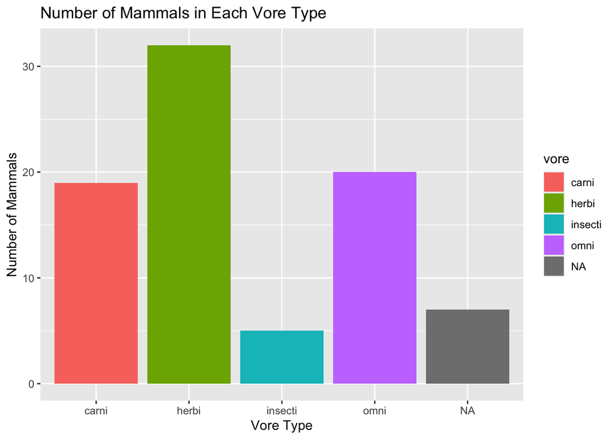

```r
ggplot(data=msleep,
       mapping=aes(x=vore))+
  geom_bar(mapping=aes(fill=vore))+
  labs(title= "Number of Mammals in Each Vore Type", x="Vore Type", y="Number of Mammals")
```

**4. What is the average length of time that mammal sleeps?**

```r
mean(msleep$sleep_total)
```

```
## [1] 10.43373
```

**5. Use `summary()` to get a quick idea of the range of values for the variable `bodywt`.**

```r
summary(msleep$bodywt)
```

```
##     Min.  1st Qu.   Median     Mean  3rd Qu.     Max.
##    0.005    0.174    1.670  166.136   41.750 6654.000
```

**6. Build a plot that shows the range of `bodywt.` by vore type. Because the range of `bodywt` is so variable, you will need to scale the y-axis. You do this by adding `scale_y_log10()` as another layer.**

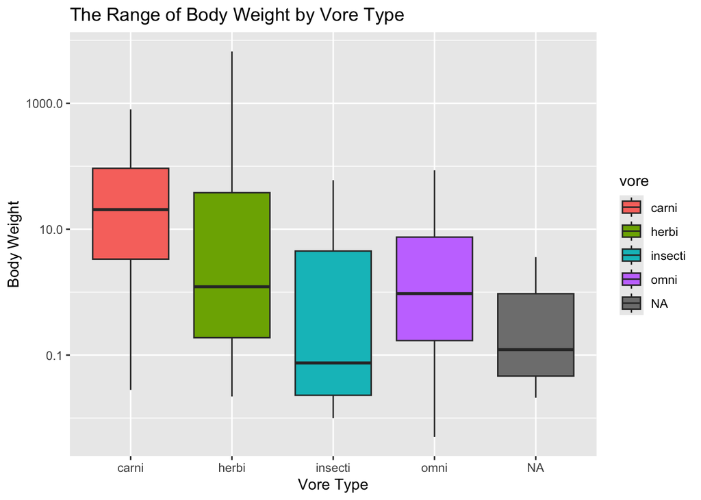

```r
ggplot(data=msleep,
       mapping=aes(x=vore, y=bodywt))+
  geom_boxplot(mapping=aes(fill=vore))+
  scale_y_log10()+
  labs(title="The Range of Body Weight by Vore Type", x="Vore Type", y= "Body Weight")
```

**7. Is there a relationship between body weight and total sleep time? Add appropriate labels and a title to your plot.**

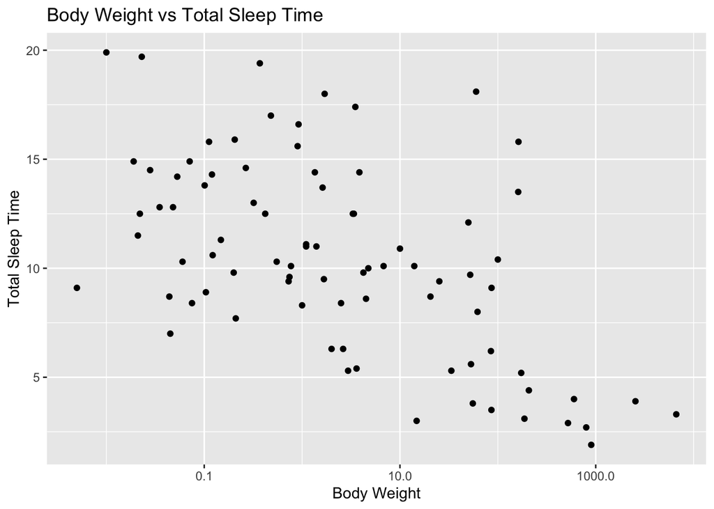

```r
ggplot(data=msleep,
       mapping=aes(x=bodywt, y=sleep_total))+
  geom_point()+
  scale_x_log10()+
  labs(title="Body Weight vs Total Sleep Time", x="Body Weight", y= "Total Sleep Time")
```

**8. Which vore type tends to sleep the most? Build a plot to support your answer.**

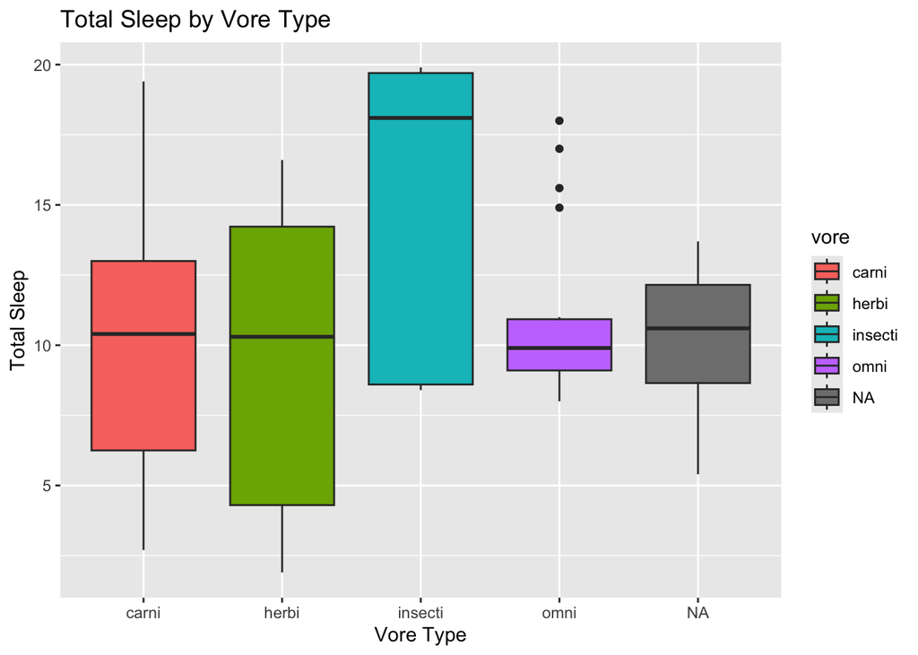

```r
ggplot(data=msleep,
       mapping=aes(x=vore, y=sleep_total))+
  geom_boxplot(mapping=aes(fill=vore))+
  labs(title= "Total Sleep by Vore Type", x= "Vore Type", y = "Total Sleep")
```

**9. Is there a relationship between brain weight and body weight? Build a plot to support your answer.**

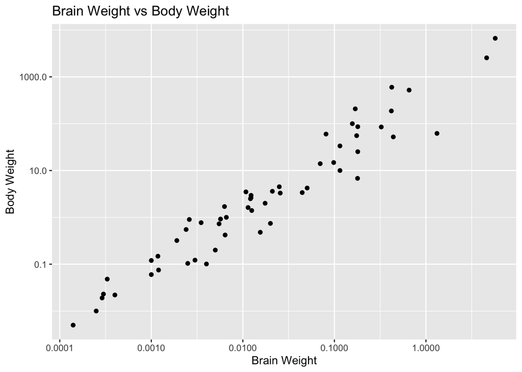

```r
ggplot(data=msleep,
       mapping=aes(x=brainwt, y=bodywt))+
  geom_point()+
  scale_x_log10()+
  scale_y_log10()+
labs(title= "Brain Weight vs Body Weight", x= "Brain Weight", y= "Body Weight")
```

**10. Build one plot of your choice that provides additional insight into the msleep dataset. Be sure to include appropriate labels and a title.**

#The Relationship Between Brain Weight and The Amount of Sleep Spent in REM

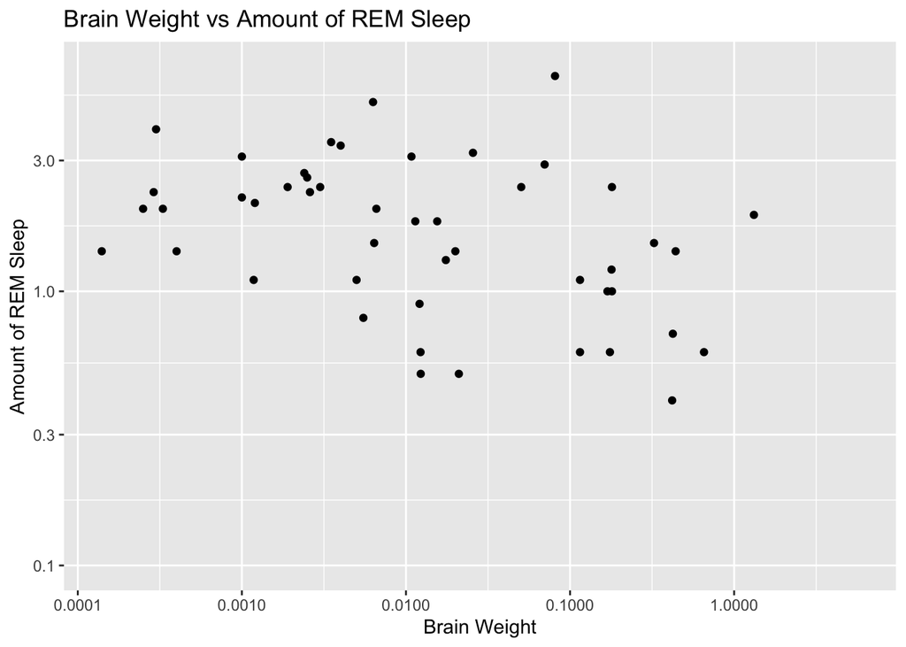

```r
ggplot(data=msleep,
       mapping=aes(x=brainwt, y=sleep_rem))+
  geom_point(mapping=aes())+
    labs(title = "Brain Weight vs Amount of REM Sleep", x= "Brain Weight", y="Amount of REM Sleep")+
      scale_y_log10()+
      scale_x_log10()
```

## Knit and Upload

Please knit your work as an .html file and upload to Canvas. Homework is due before the start of the next lab. No late work is accepted. Make sure to use the formatting conventions of RMarkdown to make your report neat and clean!